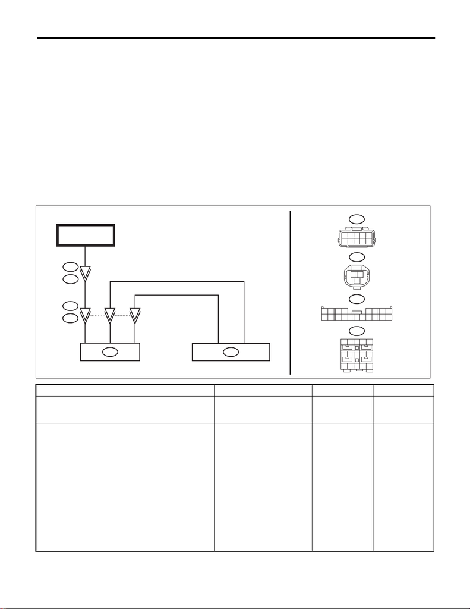

OD(diag)-19

Diagnostic Procedure with Diagnostic Trouble Code (DTC)

OCCUPANT DETECTION SYSTEM (DIAGNOSTICS)

15.Diagnostic Procedure with Diagnostic Trouble Code (DTC)

A: DTC B1650 OCCUPANT CLASSIFICATION SYSTEM MALFUNCTION

DIAGNOSIS START CONDITION:

When the ignition voltage is 8 — 16 V.

DTC DETECTING CONDITION:

• Occupant detection sensor is faulty.

• Occupant detection control module is faulty.

• Occupant detection harness is faulty.

• Fuse No. 25 is blown out.

• Rear airbag harness is faulty.

CAUTION:

Before performing diagnosis, refer to “CAUTION” in “General Description”. <Ref. to AB(diag)-4,

CAUTION, General Description.>

WIRING DIAGRAM:

Occupant detection system <Ref. to WI-315, WIRING DIAGRAM, Occupant Detection System.>

Step Check Yes No

1 CHECK DTC.

Read the DTC of the occupant detection sys-

tem.

Is any of DTC B1760, B1761,

B1771 and B1795 detected?

Perform the diag-

nosis according to

DTC.

Go to step 2.

2 CHECK POOR CONTACT OF CONNEC-

TORS.

Check for poor contact of the connectors

between the occupant detection control module

and airbag control module.

Is there poor contact? When the connec-

tor is not fully con-

nected, reconnect

the connector cor-

rectly. Replace the

faulty harness if

the connector is

faulty. (Replace the

airbag rear har-

ness along with

body harness. Or

replace the occu-

pant detection har-

ness (seat

harness)).

Go to step 3.

8

3

76

14 15

9

10

AB18

R82

1

9

AB59

3

12

AB61

9

10

78

5

6

34

2

1

123

2

1

R82

R81

AB18

13

12

AB61

6

9

1

AB59

AB53

OCCUPANT DETECTION

CONTROL MODULE

AIRBAG CM

FB-47

F/B FUSE NO. 25

(IG)

[figure not shown]

OD(diag)-20

Diagnostic Procedure with Diagnostic Trouble Code (DTC)

OCCUPANT DETECTION SYSTEM (DIAGNOSTICS)

3 CHECK AIRBAG REAR HARNESS.

1) Turn the ignition switch to OFF, disconnect

the battery ground cable, and wait for 60 sec-

onds or more.

2) Disconnect the connectors (AB59) and

(AB53) under the passenger’s seat.

3) Disconnect the connectors (AB6, AB17,

AB18) from airbag control module.

4) Connect the connector (1AH) in the test har-

ness AH to the connectors (AB6, AB17, AB18).

5) Connect the connector (2AH) in the test har-

ness AH and the connector (1AG) in the test

harness AG.

6) Connect the connector (1AP) in the test har-

ness AP to the connector (AB53).

7) Measure the resistance between connector

(5AG) in the test harness AG and connector

(2AP) in the test harness AP.

Connector & terminal

(5AG) No. 5 — (2AP) No. 1:

(5AG) No. 16 — (2AP) No. 2:

Is the resistance less than 10

Ω?

Go to step 4. Replace the airbag

rear harness along

with body harness.

4 CHECK AIRBAG REAR HARNESS.

Measure the resistance between connector

(5AG) in the test harness AG and chassis

ground.

Connector & terminal

(5AG) No. 5 — Chassis ground:

(5AG) No. 16 — Chassis ground:

(5AG) No. 5 — (5AG) No. 16:

Is the resistance 1 MΩ or

more?

Go to step 5. Replace the airbag

rear harness along

with body harness.

5 CHECK OCCUPANT DETECTION HAR-

NESS.

1) Turn the ignition switch to ON.

2) Measure the voltage between connector

(2AP) in the test harness AP and chassis

ground.

Connector & terminal

(2AP) No. 3 (+) — Chassis ground (–):

Is the voltage 10 V or more? Replace the occu-

pant detection har-

ness (seat

harness). If defec-

tive is not

improved, replace

the occupant

detection system

(seat cushion &

frame assembly),

and then the airbag

control module in

this order. <Ref. to

SE-22, PASSEN-

GER’S SEAT, DIS-

ASSEMBLY, Front

Seat.>

Check the battery

voltage and fuse. If

there is no fault,

replace the airbag

rear harness

together with body

harness.

Step Check Yes No

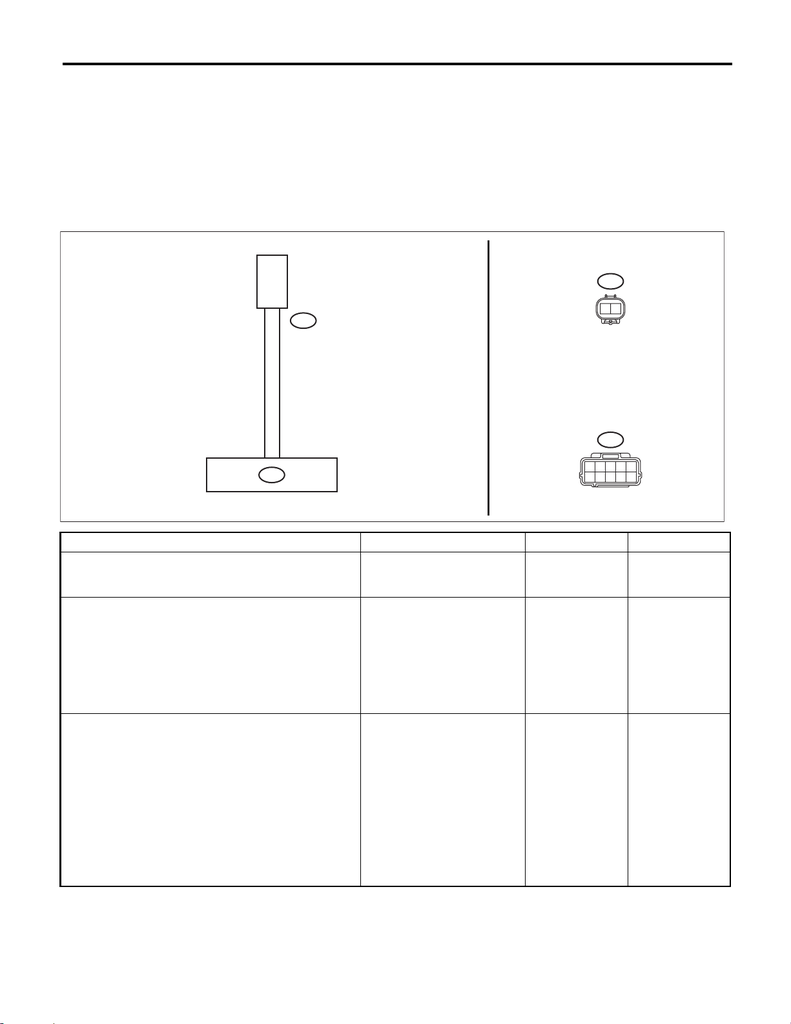

OD(diag)-21

Diagnostic Procedure with Diagnostic Trouble Code (DTC)

OCCUPANT DETECTION SYSTEM (DIAGNOSTICS)

B: DTC B1655 FRONT BUCKLE SWITCH RH FAILURE

DIAGNOSIS START CONDITION:

When the ignition voltage is 8 — 16 V.

DTC DETECTING CONDITION:

• Passenger’s buckle switch circuit is open, shorted or shorted to ground.

• Occupant detection system is faulty.

• Occupant detection harness is faulty.

WIRING DIAGRAM:

Occupant detection system <Ref. to WI-315, WIRING DIAGRAM, Occupant Detection System.>

Step Check Yes No

1 CHECK DTC.

Read the DTC of the occupant detection sys-

tem.

Is any of DTC B1760, B1761,

B1771 and B1795 detected?

Perform the diag-

nosis according to

DTC.

Go to step 2.

2 CHECK POOR CONTACT OF CONNEC-

TORS.

Check for poor contact of the connectors

between the occupant detection control module

and buckle switch.

Is there poor contact? When the connec-

tor is not fully con-

nected, reconnect

the connector cor-

rectly. Replace the

airbag harness if

the connector is

faulty.

Go to step 3.

3 CHECK BUCKLE SWITCH.

1) Turn the ignition switch to OFF, disconnect

the battery ground terminal, and wait for 60 sec-

onds.

2) Disconnect the buckle switch connector

(AB60).

3) Connect the test harness AE and test har-

ness connector Y to buckle switch connector

(AB60).

4) Connect the battery ground terminal and

turn the ignition switch to ON.

Does the airbag warning light

illuminate for 6 seconds and go

off?

Replace the buckle

switch. <Ref. to

SB-16, SEAT BELT

OUTER - FRONT,

REMOVAL, Front

Seat Belt.>

Check the seat

harness, and if any

fault is found,

replace the seat

harness. If the fault

is not fixed, replace

the occupant

detection system.

<Ref. to SE-22,

PASSENGER’S

SEAT, DISASSEM-

BLY, Front Seat.>

AB60

21

AB61

9

10

78

5

6

34

2

1

AB61

AB60

8

4

1

2

BUCKLE SWITCH

OCCUPANT DETECTION

CONTROL MODULE

[figure not shown]

OD(diag)-22

Diagnostic Procedure with Diagnostic Trouble Code (DTC)

OCCUPANT DETECTION SYSTEM (DIAGNOSTICS)

C: DTC B1760 SENSOR MAT ABNORMAL

DIAGNOSIS START CONDITION:

When the ignition voltage is 8 — 16 V.

DTC DETECTING CONDITION:

• Occupant detection sensor is faulty.

• Occupant detection sensor circuit is open, shorted between terminals, shorted to power supply or shorted

to ground.

• Seat heater circuit is open.

• Occupant detection control module is faulty.

Step Check Yes No

1 CHECK POOR CONTACT OF CONNEC-

TORS.

Check for poor contact of connectors between

the occupant detection control module and the

occupant detection sensor.

Is there poor contact of connec-

tor?

When the connec-

tor is not fully con-

nected, reconnect

the connector cor-

rectly. Replace the

faulty harness if

the connector is

faulty. (Replace the

occupant detection

harness or replace

the occupant

detection system

(passenger’s &

frame assembly)).

<Ref. to SE-22,

PASSENGER’S

SEAT, DISASSEM-

BLY, Front Seat.>

Replace the occu-

pant detection sys-

tem (passenger’s

& frame assem-

bly). <Ref. to SE-

22, PASSEN-

GER’S SEAT, DIS-

ASSEMBLY, Front

Seat.>

[figure not shown]

OD(diag)-23

Diagnostic Procedure with Diagnostic Trouble Code (DTC)

OCCUPANT DETECTION SYSTEM (DIAGNOSTICS)

D: DTC B1761 SENSOR MAT LIQUID COATING ABNORMAL

DIAGNOSIS START CONDITION:

When the ignition voltage is 8 — 16 V.

DTC DETECTING CONDITION:

• Occupant detection sensor is spattered with fluid.

• Occupant detection sensor is faulty.

• Occupant detection control module is faulty.

E: DTC B1771 BUCKLE SWITCH ABNORMAL

DIAGNOSIS START CONDITION:

When the ignition voltage is 8 — 16 V.

DTC DETECTING CONDITION:

• Passenger’s seat buckle switch is faulty.

• Passenger’s buckle switch circuit is open, shorted or shorted to ground.

• Occupant detection system is faulty.

• Occupant detection harness is faulty.

Perform the diagnosis from step 2 in “DTC B1655 FRONT BUCKLE SWITCH RH FAILURE”. <Ref. to OD(di-

ag)-21, DTC B1655 FRONT BUCKLE SWITCH RH FAILURE, Diagnostic Procedure with Diagnostic Trouble

Code (DTC).>

F: DTC B1795 ECU INTERNAL CIRCUIT FAULT

DIAGNOSIS START CONDITION:

When the ignition voltage is 8 — 16 V.

DTC DETECTING CONDITION:

Occupant detection control module is faulty.

When “DTC B1795 ECU INTERNAL CIRCUIT FAULT” is displayed, the occupant detection control module

is faulty. Replace the occupant detection system (passenger’s & frame assembly). <Ref. to SE-22, PASSEN-

GER’S SEAT, DISASSEMBLY, Front Seat.>

1) Open the vehicle windows in a well-venti-

lated place indoors and dry the seat for 24

hours.

2) Check that the seat is not wet. If the seat is

wet, extend the drying time to dry the seat well.

3) Read the DTC of the occupant detection

system.

Is DTC detected? When DTC B1761

is detected again,

replace the occu-

pant detection sys-

tem (passenger’s

& frame assem-

bly). <Ref. to SE-

22, PASSEN-

GER’S SEAT, DIS-

ASSEMBLY, Front

Seat.>

When any other

DTC is detected,

perform the diag-

nosis according to

the DTC.

Clear the memory.

[figure not shown]

OD(diag)-24

Diagnostic Procedure with Diagnostic Trouble Code (DTC)

OCCUPANT DETECTION SYSTEM (DIAGNOSTICS)

[figure not shown]

SB

Page

2. Pretensioner Connector ...........................................................................11

3. Inspection Locations after a Collision .......................................................12

4. Seat Belt Warning System .......................................................................13

5. Front Seat Belt .........................................................................................16

6. Rear Seat Belt ..........................................................................................24

7. Disposal of Pretensioner ..........................................................................29